# PDRToolboxVAST

The PhotoDissociation Region Toolbox

Marc Pound & Mark Wolfire  
University of Maryland

### A python toolkit for analyzing observations of PDRs from JWST, SOFIA, ALMA, Herschel, and many more

Thanks to our sponsors:

- NASA ADAP #80NSSC24K0634 https://dustem.astro.umd.edu
- SOFIA *FEEDBACK* Legacy Program SOF070077 https://feedback.astro.umd.edu
- JWST-ERS *PDRs4All* program ID 1288 https://pdrs4all.org

*Reliable Astrophysics at Everyday Low, Low Prices!* ®

Virtual Astronomy Software Talk 02/19/2025

### Get the PDR Toolbox

pip install pdrtpy -U

### Download the example notebooks

git clone https://github.com/mpound/pdrtpy-nb.git

This notebook is in `notebooks/PDRToolboxVAST.ipynb`

### To Learn More

Visit our website https://dustem.astro.umd.edu

Full documentation at https://pdrtpy.readthedocs.io

Our AJ paper: https://ui.adsabs.harvard.edu/abs/2023AJ....165...25P/abstract

# First, some scientific background

## What is a PDR and why should I care about them?

[figure not shown]

## What the structure of a PDR?

### Wolfire, Vallini & Chevance, ARAA, 2022

[figure not shown]

# The Orion Bar — the prototype PDR

## Credit: PDRS4All project

[figure not shown]

# How are the PDR Toolbox models calculated?

## 1. Mark Wolfire does this part

## 2. His code produced FITS files of spectral line intensities (or ratios of intensities) that are used by (distributed with) `pdrtpy`

## 3. We also provide FITS files from the KOSMA-Tau code

[figure not shown]

# Ok, onto example code!

```python
# all the imports needed for this demo
from pdrtpy.measurement import Measurement
from pdrtpy.modelset import ModelSet
from pdrtpy.tool.lineratiofit import LineRatioFit
from pdrtpy.tool.h2excitation import H2ExcitationFit
from pdrtpy.plot.modelplot import ModelPlot
from pdrtpy.plot.excitationplot import ExcitationPlot
from pdrtpy.plot.lineratioplot import LineRatioPlot
import pdrtpy.pdrutils as utils
from astropy.nddata import StdDevUncertainty
import astropy.units as u
from astropy.table import Table
import numpy as np
from astropy.logger import log
log.setLevel("CRITICAL")
```

```python
# check you have the right version.  It should be 2.4.4
import pdrtpy
pdrtpy.version()
```

```
'2.4.4'
```

# Example 1: Finding density and radiation field

This example shows use the PDRT Toolbox to determine the PDR radiation field $G_0$ and hydrogen nucleus volume density $n$ from your spectral line and far-infrared (FIR) continuum data into the PDR Toolbox. The case is for single pointing observations.

### Step 1. Input your intensity observations ("Measurements")

```python
myunit = "erg s-1 cm-2 sr-1" # default unit for value and error
m1 = Measurement(data=3.6E-4,uncertainty = StdDevUncertainty(1.2E-4),
                 identifier="OI_63",unit=myunit)
m2 = Measurement(data=1E-6,uncertainty = StdDevUncertainty([3E-7]),
                 identifier="CI_609",unit=myunit)
m3 = Measurement(data=26,uncertainty = StdDevUncertainty([5]),
                 identifier="CO_43",restfreq="461.04077 GHz",
                 unit="K km/s")
m4 = Measurement(data=8E-5,uncertainty = StdDevUncertainty([8E-6]),
                 identifier="CII_158",unit=myunit)
a = [m1,m2,m3,m4]
```

### Step 2. Choose a set of models

In this example, we choose Wolfire-Kaufman 2020 set of models with metallicity z=1. The models in this `ModelSet` are listed. We also have KOSMA-Tau models available. All models are stored as intensity or intensity ratio maps and cover [C I], [C II], [O I], $H_2$, CO and $^{13}$CO up to J=20, and more. The PDR Toolbox calculates appropriate ratios from your intensity observations, propogating errors.

```python
ms = ModelSet("wk2020",z=1)
ms.supported_ratios.show_in_notebook()
```

*Table length=74*

| idx | title | ratio label |
| --- | --- | --- |
| 0 | [O I] 63 $\mu$m / [C II] 158 $\mu$m | OI_63/CII_158 |
| 1 | ([O I] 63 $\mu$m + [C II] 158 $\mu$m) / I$_{FIR}$ | OI_63+CII_158/FIR |
| 2 | ([O I] 145 $\mu$m + [C II] 158 $\mu$m) / I$_{FIR}$ | OI_145+CII_158/FIR |
| 3 | [O I] 145 $\mu$m / [O I] 63 $\mu$m | OI_145/OI_63 |
| 4 | [C I] 370 $\mu$m / [C I] 609 $\mu$m | CI_370/CI_609 |
| 5 | [C II] 158 $\mu$m / [C I] 609 $\mu$m | CII_158/CI_609 |
| 6 | [C II] 158 $\mu$m / [O I] 145 $\mu$m | CII_158/OI_145 |
| 7 | [C II] 158 $\mu$m / I$_{FIR}$ | CII_158/FIR |
| 8 | [C II] 158 $\mu$m / CO(J=1-0) | CII_158/CO_10 |
| 9 | [C II] 158 $\mu$m / CO(J=2-1) | CII_158/CO_21 |
| 10 | [C II] 158 $\mu$m / CO(J=3-2) | CII_158/CO_32 |
| 11 | [C II] 158 $\mu$m / CO(J=6-5) | CII_158/CO_65 |
| 12 | [C II] 158 $\mu$m / $^{13}$CO(J=1-0) | CII_158/13CO_10 |
| 13 | CO(J=2-1) / CO(J=1-0) | CO_21/CO_10 |
| 14 | CO(J=3-2) / CO(J=1-0) | CO_32/CO_10 |
| 15 | CO(J=3-2) / CO(J=2-1) | CO_32/CO_21 |
| 16 | [C I] 609 $\mu$m / CO(J=4-3) | CI_609/CO_43 |
| 17 | [C I] 609 $\mu$m / CO(J=2-1) | CI_609/CO_21 |
| 18 | [C I] 609 $\mu$m / CO(J=1-0) | CI_609/CO_10 |
| 19 | [C I] 609 $\mu$m / $^{13}$CO(J=1-0) | CI_609/13CO_10 |
| 20 | [C I] 609 $\mu$m / $^{13}$CO(J=2-1) | CI_609/13CO_21 |
| 21 | [C I] 609 $\mu$m / $^{13}$CO(J=3-2) | CI_609/13CO_32 |
| 22 | CO(J=4-3) / CO(J=2-1) | CO_43/CO_21 |
| 23 | CO(J=6-5) / CO(J=1-0) | CO_65/CO_10 |
| 24 | CO(J=7-6) / CO(J=1-0) | CO_76/CO_10 |
| 25 | CO(J=7-6) / CO(J=2-1) | CO_76/CO_21 |
| 26 | CO(J=7-6) / CO(J=4-3) | CO_76/CO_43 |
| 27 | CO(J=7-6) / CO(J=5-4) | CO_76/CO_54 |
| 28 | CO(J=7-6) / CO(J=6-5) | CO_76/CO_65 |
| 29 | CO(J=8-7) / CO(J=5-4) | CO_87/CO_54 |
| 30 | CO(J=8-7) / CO(J=6-5) | CO_87/CO_65 |
| 31 | CO(J=9-8) / CO(J=5-4) | CO_98/CO_54 |
| 32 | CO(J=9-8) / CO(J=6-5) | CO_98/CO_65 |
| 33 | CO(J=10-9) / CO(J=5-4) | CO_109/CO_54 |
| 34 | CO(J=10-9) / CO(J=6-5) | CO_109/CO_65 |
| 35 | CO(J=10-9) / CO(J=7-6) | CO_109/CO_76 |
| 36 | CO(J=11-10) / CO(J=5-4) | CO_1110/CO_54 |
| 37 | CO(J=11-10) / CO(J=6-5) | CO_1110/CO_65 |
| 38 | CO(J=12-11) / CO(J=5-4) | CO_1211/CO_54 |
| 39 | CO(J=12-11) / CO(J=6-5) | CO_1211/CO_65 |
| 40 | CO(J=13-12) / CO(J=5-4) | CO_1312/CO_54 |
| 41 | CO(J=13-12) / CO(J=6-5) | CO_1312/CO_65 |
| 42 | CO(J=14-13) / CO(J=5-4) | CO_1413/CO_54 |
| 43 | CO(J=14-13) / CO(J=6-5) | CO_1413/CO_65 |
| 44 | CO(J=15-14) / CO(J=5-4) | CO_1514/CO_54 |
| 45 | CO(J=15-14) / CO(J=6-5) | CO_1514/CO_65 |
| 46 | CO(J=16-15) / CO(J=5-4) | CO_1615/CO_54 |
| 47 | CO(J=16-15) / CO(J=6-5) | CO_1615/CO_65 |
| 48 | CO(J=17-16) / CO(J=5-4) | CO_1716/CO_54 |
| 49 | CO(J=17-16) / CO(J=6-5) | CO_1716/CO_65 |
| 50 | CO(J=18-17) / CO(J=5-4) | CO_1817/CO_54 |
| 51 | CO(J=18-17) / CO(J=6-5) | CO_1817/CO_65 |
| 52 | $^{13}$CO(J=1-0) / CO(J=1-0) | 13CO_10/CO_10 |
| 53 | $^{13}$CO(J=2-1) / CO(J=2-1) | 13CO_21/CO_21 |
| 54 | $^{13}$CO(J=3-2) / CO(J=2-1) | 13CO_32/CO_21 |
| 55 | $^{13}$CO(J=4-3) / CO(J=2-1) | 13CO_43/CO_21 |
| 56 | $^{13}$CO(J=5-4) / CO(J=2-1) | 13CO_54/CO_21 |
| 57 | $^{13}$CO(J=6-5) / CO(J=2-1) | 13CO_65/CO_21 |
| 58 | $^{13}$CO(J=7-6) / CO(J=2-1) | 13CO_76/CO_21 |
| 59 | $^{13}$CO(J=3-2) / $^{13}$CO(J=1-0) | 13CO_32/13CO_10 |
| 60 | H$_2$0-0S(2) 12.3 $\mu$m / H$_2$0-0S(0) 28.2 $\mu$m | H200S2/H200S0 |
| 61 | H$_2$0-0S(2) 12.3 $\mu$m / H$_2$0-0S(1) 17 $\mu$m | H200S2/H200S1 |
| 62 | H$_2$0-0S(3) 9.7 $\mu$m / H$_2$0-0S(0) 28.2 $\mu$m | H200S3/H200S0 |
| 63 | H$_2$0-0S(3) 9.7 $\mu$m / H$_2$0-0S(1) 17 $\mu$m | H200S3/H200S1 |
| 64 | H$_2$0-0S(3) 9.7 $\mu$m / H$_2$0-0S(2) 12.3 $\mu$m | H200S3/H200S2 |
| 65 | H$_2$2-1S(1) 2.24 $\mu$m / H$_2$1-0S(1) 2.12 $\mu$m | H221S1/H210S1 |
| 66 | [Fe II] 1.60 $\mu$m/[Fe II] 1.64 $\mu$m | FEII_1.60/FEII_1.64 |
| 67 | [Fe II] 1.64 $\mu$m/[Fe II] 5.34 $\mu$m | FEII_1.64/FEII_5.34 |
| 68 | [Fe II] 5.67 $\mu$m/[Fe II] 5.34 $\mu$m | FEII_5.67/FEII_5.34 |
| 69 | [Fe II] 17.94 $\mu$m/[Fe II] 5.34 $\mu$m | FEII_17.94/FEII_5.34 |
| 70 | [Fe II] 22.90 $\mu$m/[Fe II] 5.34 $\mu$m | FEII_22.90/FEII_5.34 |
| 71 | [Fe II] 25.99 $\mu$m/[Fe II] 5.34 $\mu$m | FEII_26/FEII_5.34 |
| 72 | [Ar III] 21.83 $\mu$m/[Ar III] 8.99 $\mu$m | ARIII_21.83/ARIII_8.99 |
| 73 | [Ar V] 13.07 $\mu$m/[Ar V] 7.91 $\mu$m | ARV_13.07/ARV_7.91 |

### Step 3. Create the fitter and run it.

This example uses the default least-squares fitting; MCMC is also available. The results are stored in member variables as `Measurements` and in an `lmfit.ModelResult` object.

```python
p = LineRatioFit(ms,measurements=a)
p.run()
```

```
Converting K km/s to erg / (s sr cm2) using Factor = +1.004E-07 g / (K cm s2)
fitted 1 of 1 pixels
got 0 exceptions
```

```python
p.fit_result[0]
```

Fit Result

Fit Statistics

| fitting method | leastsq |
| --- | --- |
| # function evals | 13 |
| # data points | 3 |
| # variables | 2 |
| chi-square | 0.04123761 |
| reduced chi-square | 0.04123761 |
| Akaike info crit. | -8.86105089 |
| Bayesian info crit. | -10.6638263 |

Parameters

| name | value | standard error | relative error | initial value | min | max | vary |
| --- | --- | --- | --- | --- | --- | --- | --- |
| density | 40730.7043 | 2467.21840 | (6.06%) | 42169.65034285822 | 10.0000000 | 10000000.0 | True |
| radiation_field | 0.35817960 | 0.03950398 | (11.03%) | 0.37941973904039467 | 5.0596e-04 | 5059.64354 | True |

Correlations (unreported values are < 0.100)

| Parameter1 | Parameter 2 | Correlation |
| --- | --- | --- |
| density | radiation_field | -0.3572 |

## Step 5: Visualize the results

Create a plotter and feed it the LineRatioFit object. Then you can call various methods to plot the fit. Here are three examples:

- Your observed ratios with errors on their matching models in $(n,G_0)$ space
- The reduced $\chi^2$ plot of the fit as a function of $(n,G_0)$
- An overlay of all your observed ratios with errors in the model $(n,G_0)$ space

Note we choose to plot radiation field in Habing units, but common alternatives Draine, Mathis, and cgs units are supported.

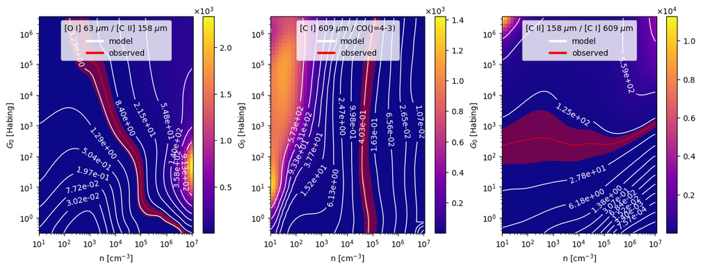

```python
plot = LineRatioPlot(p)
plot.ratios_on_models(yaxis_unit="Habing",image=True,norm='simple',
                      ncols=3, cmap='plasma',
                       meas_color=['red'],label=True,colorbar=True)
# Save the figure to a PNG
plot.savefig("modelfits.png")
```

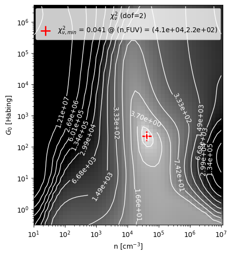

```python
plot.reduced_chisq(cmap='gray_r',norm='log',label=True,
                   colors='white', legend=True,vmax=8E4,
                   yaxis_unit='Habing',
                   figsize=(5,7))
```

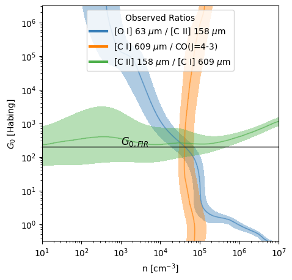

```python
plot.overlay_all_ratios(yaxis_unit="Habing",figsize=(5,5))
# add a marker for G0 as determined from FIR observations
plot.text(1000,240,r"$G_{0,FIR}$",fontsize='large',color='k')
plot._plt.hlines(200,10,1E7,color='k',linewidth=1)
```

### You can also fit maps!

Here we use [C II], [O I], and FIR maps of the SMC molecular cloud N22 from [Jameson et al. 2018](https://ui.adsabs.harvard.edu/abs/2018ApJ...853..111J/abstract) and a custom `ModelSet` for the SMC.

```python
cii_meas = Measurement.read("../data/n22_cii_flux_error.fits",
                            identifier="CII_158")
FIR_meas = Measurement.read("../data/n22_FIR_flux_error.fits",
                            identifier="FIR")
oi_meas = Measurement.read("../data/n22_oi_flux_error.fits",
                           identifier="OI_63")

smcmod = ModelSet("smc",z=0.1)
p = LineRatioFit(modelset=smcmod,
                 measurements=[cii_meas,FIR_meas,oi_meas])
p.run()
```

```
fitted 4768 of 11259 pixels
got 0 exceptions
```

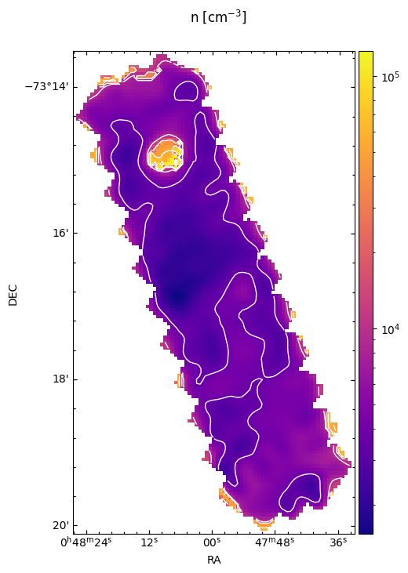

```python
plot = LineRatioPlot(p)
plot.density(contours=True,norm="log",figsize=(5,8))
```

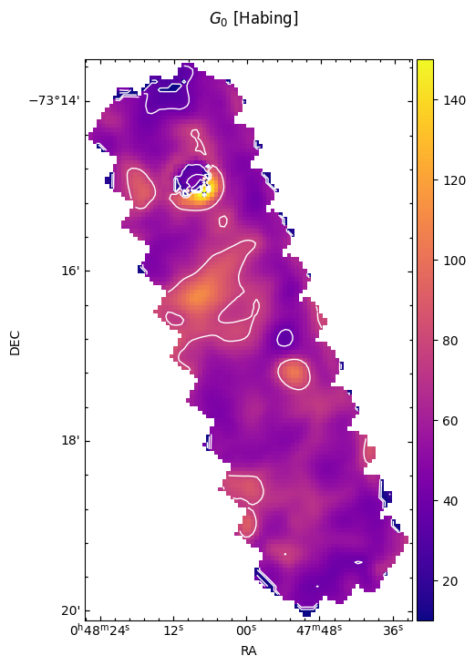

```python
plot.radiation_field(units="Habing",contours=True,
                     norm="simple",figsize=(5,8))
```

# Example 2: $H_2$ Excitation Diagrams

This example will go through the steps of computing the temperature and column density using $H_2$ line intensities plotted in an excitation diagram. We will show fitting of an excitation diagram comprised of single pointing `Measurements`, both with fixed ortho-to-para ratio (OPR) and allowing OPR to vary. The data are from [Sheffer et al 2011](https://iopscience.iop.org/article/10.1088/0004-637X/741/1/45/pdf).

### As before, you input intensities as `Measurements`, instantiate a fitter, run it, and look at results.

```python
intensity = dict()
intensity['H200S0'] = 3.003e-05
intensity['H200S1'] = 3.143e-04
intensity['H200S2'] = 3.706e-04
intensity['H200S3'] = 1.060e-03
intensity['H200S4'] = 5.282e-04
intensity['H200S5'] = 5.795e-04
a = []
for i in intensity:
    m = Measurement(data=intensity[i],
                    uncertainty=StdDevUncertainty(0.75*intensity[i]),
                    identifier=i,unit="erg cm-2 s-1 sr-1")
    a.append(m)
```

```python
h = H2ExcitationFit(a)
h.run()
print('T(cold) = {:>8.2f}'.format(h.tcold))
print('T(hot) = {:>8.2f}'.format(h.thot))
print(f'N(cold) = {h.cold_colden:3.2E}')
print(f'N(hot) = {h.hot_colden:3.2E}')
print(f'N(total) = {h.total_colden:+.1e}')
```

```
T(cold) =   123.77 +/-    88.62 K
T(hot) =   633.39 +/-    59.82 K
N(cold) = 5.64E+21 +/- 1.67E+22 1 / cm2
N(hot) = 2.25E+20 +/- 1.10E+20 1 / cm2
N(total) = +5.9e+21 +/- +1.7e+22 1 / cm2
```

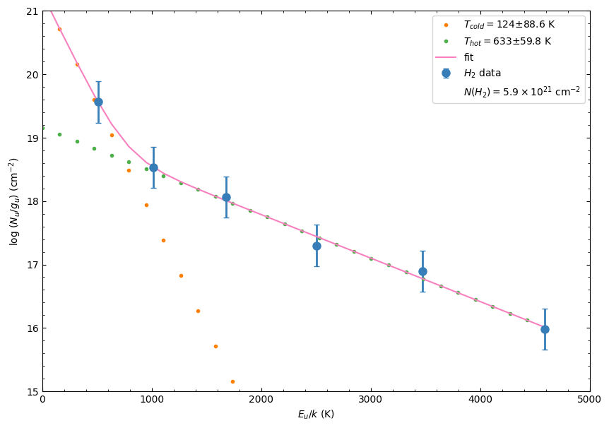

```python
hplot = ExcitationPlot(h,"H_2")
hplot.ex_diagram(show_fit=True,ymax=21)
```

### The first fit looked ok, but we can do better by allowing the Ortho-to-Para Ratio (OPR) to vary as well.

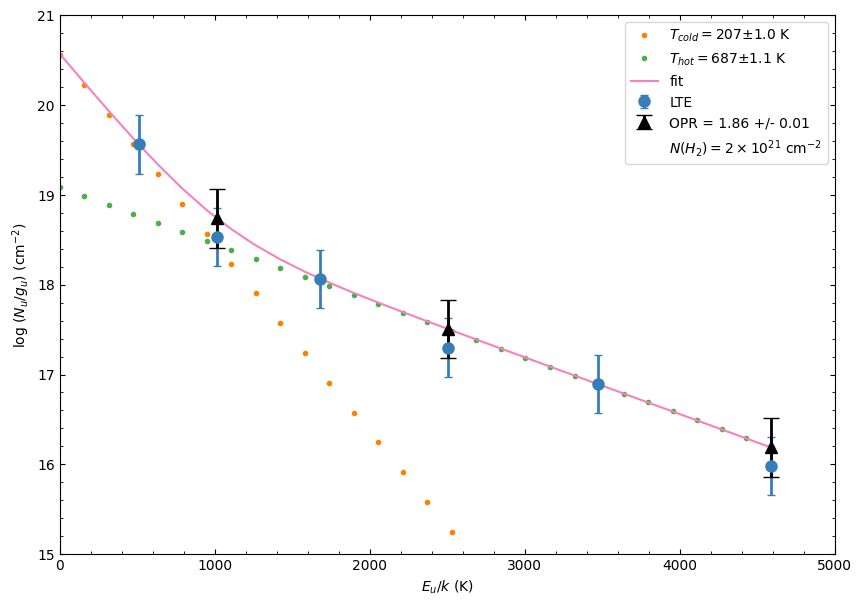

```python
h.run(fit_opr=True)
hplot.ex_diagram(show_fit=True,ymax=21)
```

# Example 3: Phase space and isocontour plots

As phase space plot shows ayn model ratio against any other model ratio (or model intensity) on which you can overlay observations. In these examples we use the [H II] region diagnostic lines of Fe and Ar. You create a `ModelPlot` with your chosen `ModelSet` and away you go!

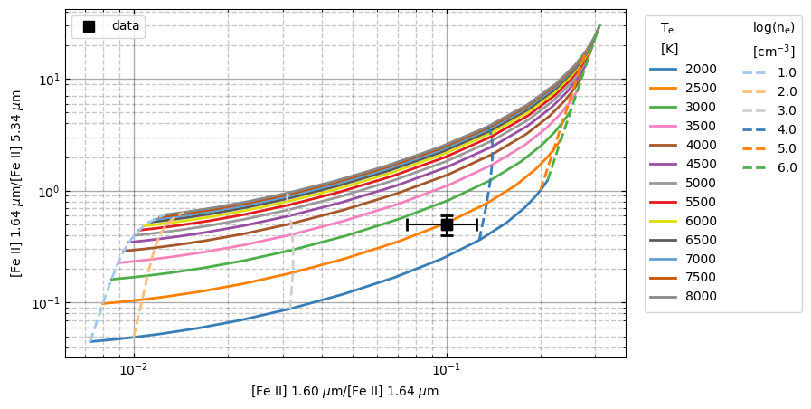

```python
mp = ModelPlot(ms)
m1 = Measurement(data=[0.1],
                 uncertainty = StdDevUncertainty(0.025),
                 identifier="FEII_1.60/FEII_1.64",unit="")
m2 = Measurement(data=[0.5],
                 uncertainty = StdDevUncertainty(0.1),
                 identifier="FEII_1.64/FEII_5.34",unit="")
mp.phasespace(['FEII_1.60/FEII_1.64','FEII_1.64/FEII_5.34'],
              nax1_clip=[2E3,8E3]*u.Unit("K"),
              nax2_clip=[10,1E6]*u.Unit("cm-3"),
              measurements=[m1,m2],errorbar=True)
```

## You can make isocontour plots of individual model parameters

Related to the phase space plot is the `isoplot`, which will plot one of the model axes versus model value (intensity or intensity ratio) and draw on it iso-lines of the other model axis.

In the example below, we plot lines of constant electron gas temperature $T_e$ (isotherms) as a function of electron gas density $n_e$ and [Ar III] 21.83 $\mu$m / [Ar III] 8.99 $\mu$m intensity ratio. In our ionized gas models, $T_e$ is on FITS `NAXIS1` and $n_e$ is on `NAXIS2`.

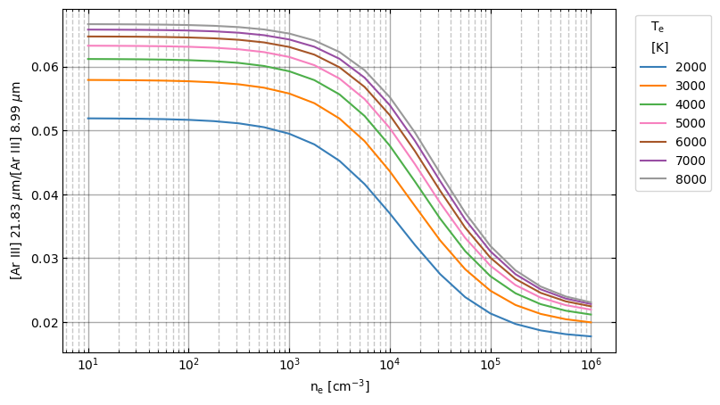

```python
nax1clip = [2000,8000]*u.Unit("K")
# step=N means plot every N-th line in the given range.
# This helps avoid crowding on the plot.
mp.isoplot("ARIII_21.83/ARIII_8.99",
           plotnaxis=1,logx=True,
           nax_clip=nax1clip,step=2)
```

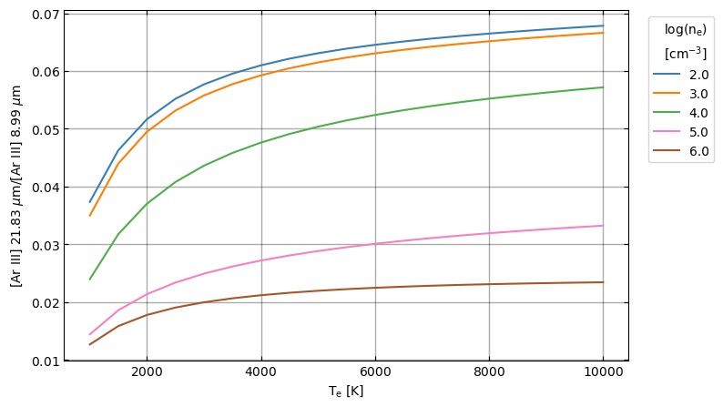

```python
# Plotting the other model axis is easy,
# just change plotnaxis and the clip values and units
nax1clip = [100,1E7]*u.Unit("cm-3")
mp.isoplot("ARIII_21.83/ARIII_8.99",
           plotnaxis=2,nax_clip=nax1clip,logx=False)
```

There is much more the PDR Toolbox can do.  
We encourage you to download it and see for yourself!

### We also welcome development. Fork us on github! https://github.com/mpound/pdrtpy